# R Notebook

```r
library(tidyverse)
library(ggthemes)
backpack <- CodeClanData::backpack
```

# MVP

## Question 1

Load in the libraries you need, and look at the backpack data. Take note of variable names and dimensions.

```r
backpack <- backpack %>%
  mutate(back_problems = as.logical(back_problems))
dim(backpack)
```

```
[1] 100   9
```

```r
glimpse(backpack)
```

```
Rows: 100
Columns: 9
$ backpack_weight <int> 9, 8, 10, 6, 8, 5, 8, 4, 5, 2, 8, 21, 11, 11, 12, 11, 13, 6, 10, 5, 20, 14, 11, 15, …
$ body_weight     <int> 125, 195, 120, 155, 180, 240, 170, 185, 130, 120, 135, 160, 170, 170, 125, 175, 145,…
$ ratio           <dbl> 0.0720000, 0.0410256, 0.0833333, 0.0387097, 0.0444444, 0.0208333, 0.0470588, 0.02162…
$ back_problems   <lgl> TRUE, FALSE, TRUE, FALSE, FALSE, FALSE, FALSE, TRUE, FALSE, FALSE, FALSE, FALSE, FAL…
$ major           <fct> Bio, Philosophy, GRC, CSC, EE, History, CM, ARCE, Bio, Bio, Bus, ME, CPE, CPE, CS, C…
$ year            <int> 3, 5, 4, 6, 2, 0, 3, 5, 4, 5, 3, 5, 4, 4, 3, 4, 4, 3, 3, 3, 2, 2, 5, 5, 3, 1, 4, 2, …
$ sex             <fct> Female, Male, Female, Male, Female, Male, Male, Female, Female, Female, Female, Male…
$ status          <fct> U, U, U, G, U, G, U, U, U, U, U, U, U, U, U, U, U, U, U, U, U, U, U, U, U, U, U, U, …
$ units           <int> 13, 12, 14, 0, 14, 0, 15, 18, 14, 8, 15, 12, 16, 16, 12, 16, 16, 16, 17, 14, 16, 12,…
```

## Question 2

What is the distribution of backpack weights that students are carrying? Choose an appropriate graph to show the distribution.

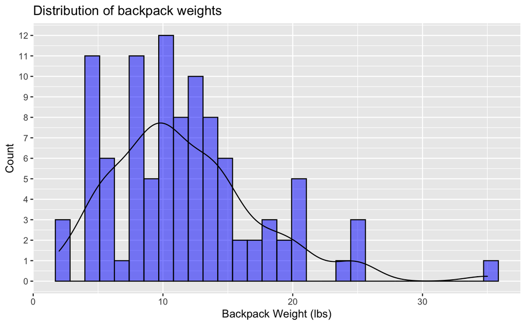

```r
ggplot(backpack) +
  aes(x = backpack_weight) +
  geom_histogram( fill = "blue", colour = "black", bins = 30, alpha = 0.5) +
  geom_density(aes(y = ..count..)) +
  labs(
    x = "Backpack Weight (lbs)",
    y = "Count",
    title = "Distribution of backpack weights"
  ) +
  scale_y_continuous(breaks = 0:13)
```

From the graph we can see that the majority of backpack weight fall below 15lbs. However there is one outlier of over 30 lbs.

## Question 3

Are there differences in backpack weight between sex?

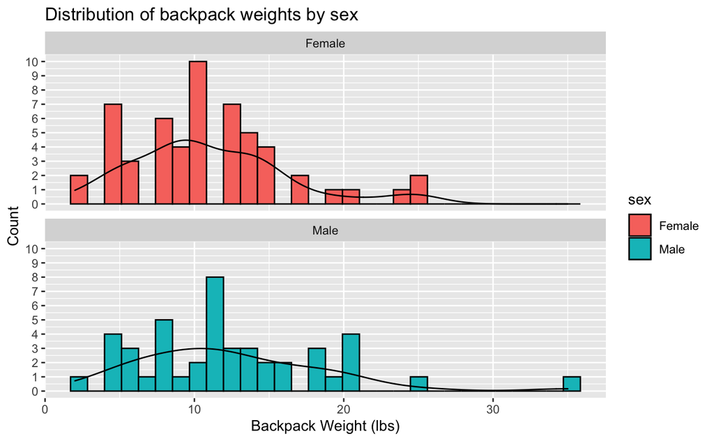

```r
ggplot(backpack) +
  aes(x = backpack_weight) +
  geom_histogram( colour = "black", bins = 30, aes(fill = sex)) +
  geom_density(aes(y = ..count..)) +
  facet_wrap(~ sex, ncol  = 1) +
  labs(
    x = "Backpack Weight (lbs)",
    y = "Count",
    title = "Distribution of backpack weights by sex"
  ) +
  scale_y_continuous(breaks = 0:13)
```

```r
NA
NA
```

We can see that more females have lighter backpacks, whilst males tend to have a more even distribution of back packs

## Question 4

What is the relationship between body weight and backpack weight?

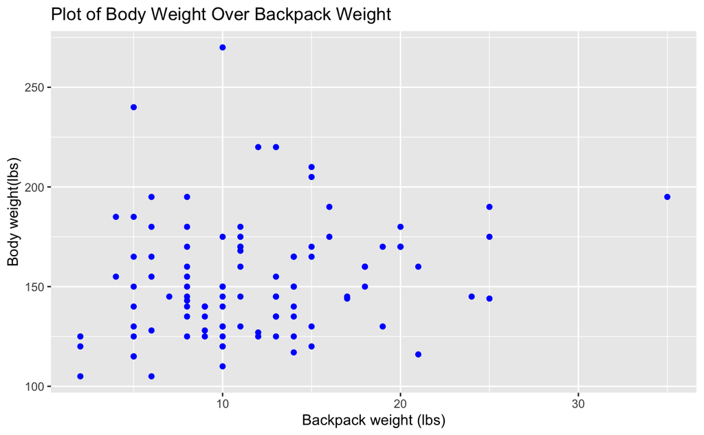

```r
ggplot(backpack) +
  aes(x= backpack_weight, y = body_weight) +
  geom_point(colour = "blue") +
  labs(x = "Backpack weight (lbs)",
       y = "Body weight(lbs)",
       title = "Plot of Body Weight Over Backpack Weight")
```

THere is no clear relationship between backpack weight and bodyweight

## Question 5

Is this relationship different between men and women? Choose an appropriate plot and interpret your findings.

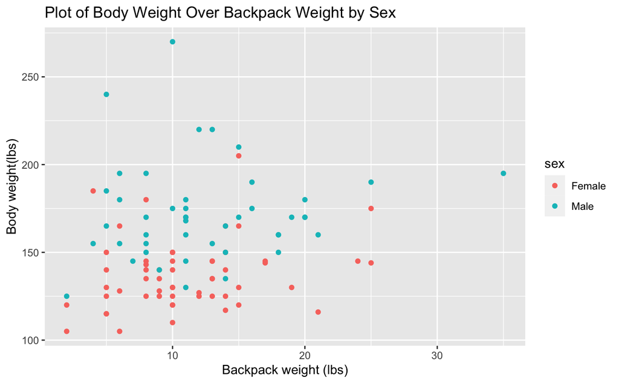

```r
ggplot(backpack) +
  aes(x= backpack_weight, y = body_weight,colour = sex) +
  geom_point() +
  labs(x = "Backpack weight (lbs)",
       y = "Body weight(lbs)",
       title = "Plot of Body Weight Over Backpack Weight by Sex")
```

Again there is no obviously relationshop between men and women. Women tend to have a heavier backpack for their bodyweight.

## Question 6

What proportion of students report back pain?

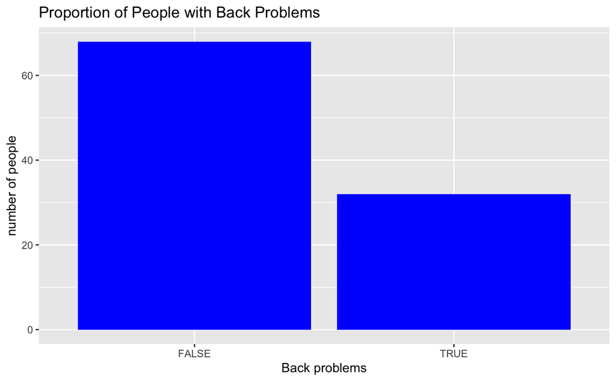

```r
backpack %>%
  mutate(back_problems = as.logical(back_problems)) %>%
  ggplot() +
  aes(x= back_problems) +
  geom_bar(fill = "blue") +
  labs(
    x = "Back problems",
    y = "number of people",
    title = "Proportion of People with Back Problems"
  )
```

```r
NA
```

As we can see the majoity of people do not suffer from back problem

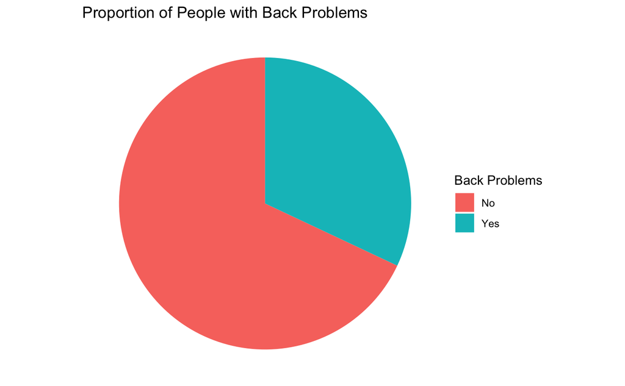

```r
backpack %>%
  mutate(back_problems = ifelse(back_problems == TRUE, "Yes", "No")) %>%
  group_by(back_problems) %>%
  summarise(count = n()) %>%
  ggplot() +
  aes(x="", y = count, fill = back_problems) +
  coord_polar("y", start=0) +
  geom_bar(stat = "identity") +
  labs(
    fill = "Back Problems",
    title = "Proportion of People with Back Problems"
  ) +
  theme_void()
```

```r
NA
```

## Question 7.

Is this proportion different between men and women?

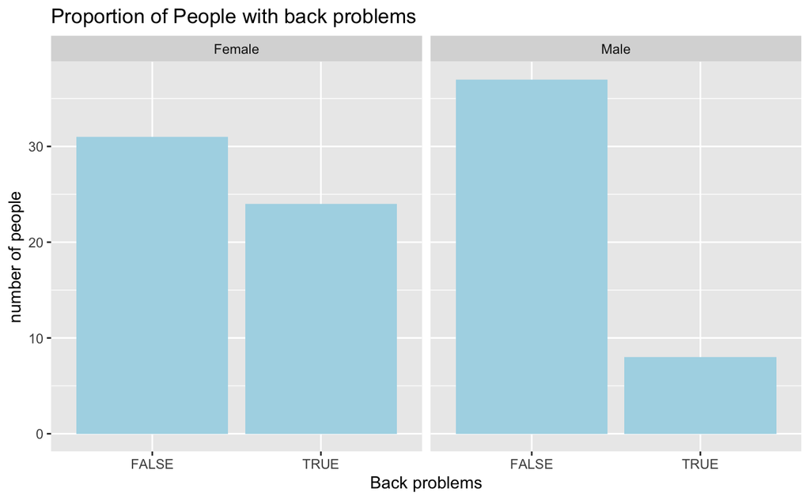

```r
  ggplot(backpack) +
  aes(x= back_problems) +
  geom_bar(fill = "light blue") +
  labs(
    x = "Back problems",
    y = "number of people",
    title = "Proportion of People with back problems"
  ) +
  facet_wrap(~ sex)
```

```r
NA
NA
```

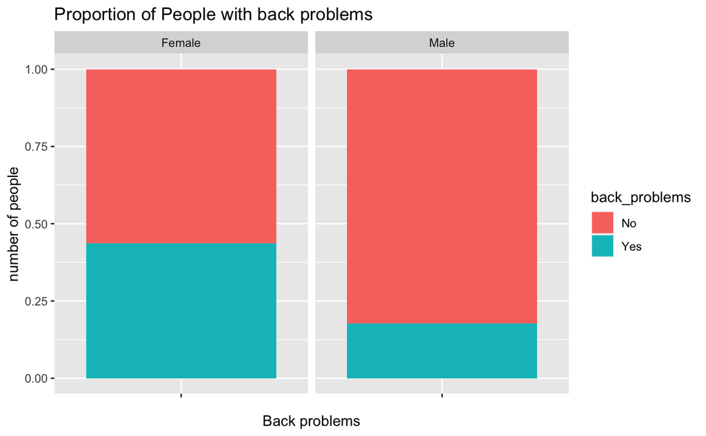

```r
backpack %>%
mutate(back_problems = ifelse(back_problems == TRUE, "Yes", "No")) %>%
  group_by(back_problems, sex) %>%
  summarise(count = n()) %>%
  ggplot() +
  aes(x= "", y = count, fill = back_problems ) +
  geom_bar(stat= "identity", position = "fill") +
  labs(
    x = "Back problems",
    y = "number of people",
    title = "Proportion of People with back problems"
  ) +
  facet_wrap(~ sex)
```

```r
NA
NA
```

## Question 8

Now you’ve investigated your data separately, create plots to describe the relationship between backpack weight, body weight, gender and reported backpain.

Try both backpack_weight and body_weight as well as the ratio.

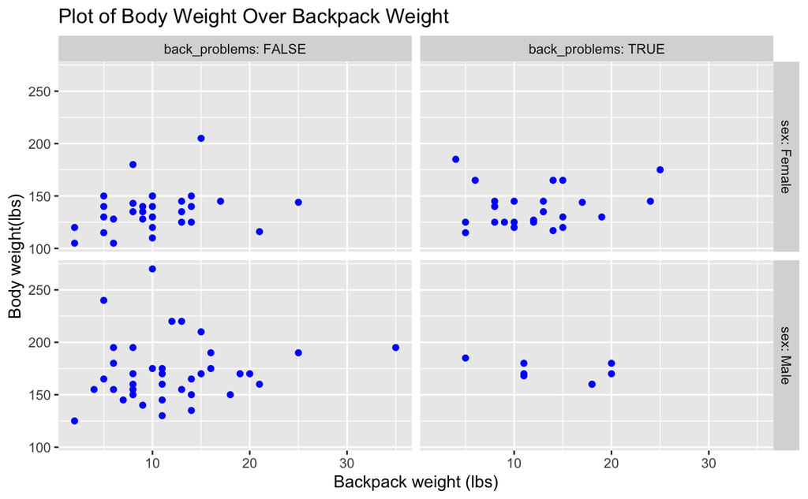

```r
ggplot(backpack) +
  aes(x= backpack_weight, y = body_weight) +
  geom_point(colour = "blue") +
  labs(x = "Backpack weight (lbs)",
       y = "Body weight(lbs)",
       title = "Plot of Body Weight Over Backpack Weight") +
  facet_grid(sex ~ back_problems, labeller = "label_both" )
```

```r
NA
NA
```

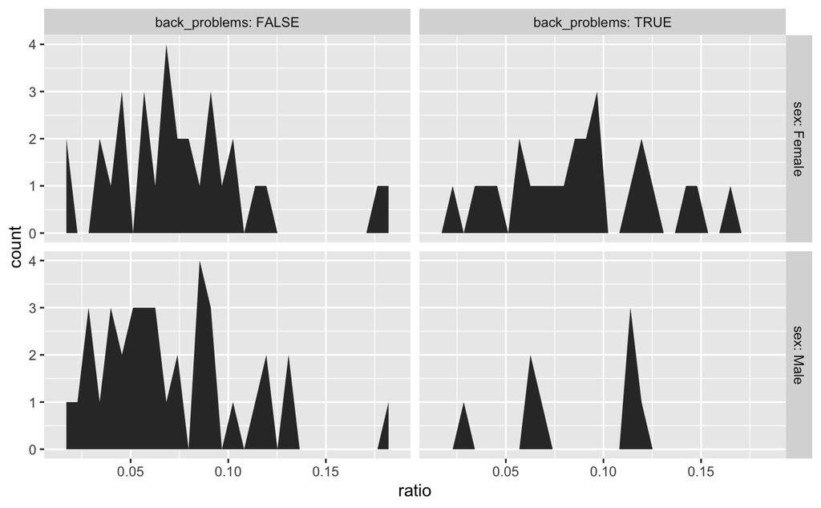

```r
ggplot(backpack) +
  aes(x= ratio) +
  geom_area(stat = "bin") +
  facet_grid(sex ~ back_problems, labeller = "label_both")
```

Does reported backpain differ across the year groups? Ignore year 0 in your data.

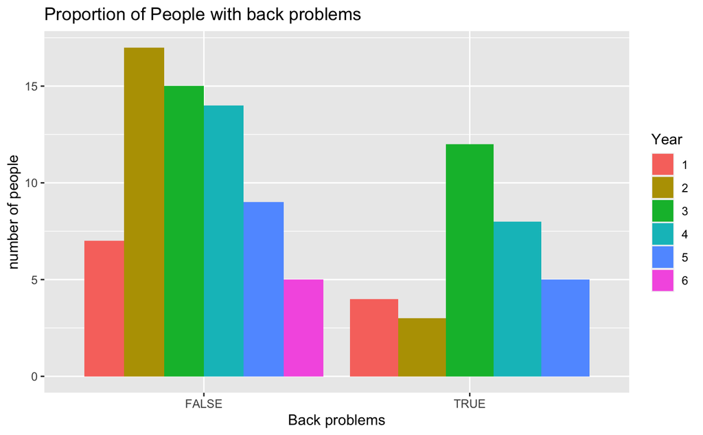

```r
backpack %>%
  filter(year > 0) %>%
  mutate(year = as.character(year)) %>%
   ggplot() +
  aes(x= back_problems, fill = year) +
  geom_bar( position = "dodge") +
  labs(
    x = "Back problems",
    y = "number of people",
    title = "Proportion of People with back problems",
    fill = "Year")
```

# Question 2.

Is there a difference between how heavy the bags those in different years carry?

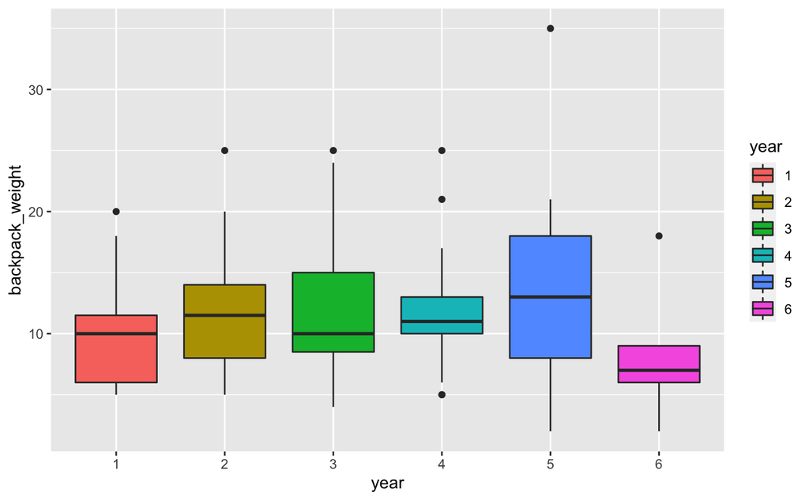

```r
backpack %>%
  filter(year > 0) %>%
  mutate(year = as.character(year)) %>%
ggplot() +
  aes(y = backpack_weight,  x = year, fill = year) +
  geom_boxplot()
```